# Session 8: Plots in R with ggplot2

**Interactive mode:** click a code block or *Show Plot* button to reveal/hide its corresponding plot.

## Week 8 Plots in R - ggplot2

## **1. Introduction to Data**

We’ll use the **NHANES dataset**, which contains demographic, health, and lifestyle data from a U.S. population survey.

```r
library("NHANES")
library(tidyverse)
library(ggplot2)
library(haven)
data("NHANES")

data<-data.frame(NHANES)
```

```r
glimpse(data)
```

```
## Rows: 10,000
## Columns: 76
## $ ID               <int> 51624, 51624, 51624, 51625, 51630, 51638, 51646, 51647, 51647, 51647, 516…
## $ SurveyYr         <fct> 2009_10, 2009_10, 2009_10, 2009_10, 2009_10, 2009_10, 2009_10, 2009_10, 2…
## $ Gender           <fct> male, male, male, male, female, male, male, female, female, female, male,…
## $ Age              <int> 34, 34, 34, 4, 49, 9, 8, 45, 45, 45, 66, 58, 54, 10, 58, 50, 9, 33, 60, 1…
## $ AgeDecade        <fct>  30-39,  30-39,  30-39,  0-9,  40-49,  0-9,  0-9,  40-49,  40-49,  40-49,…
## $ AgeMonths        <int> 409, 409, 409, 49, 596, 115, 101, 541, 541, 541, 795, 707, 654, 123, 700,…
## $ Race1            <fct> White, White, White, Other, White, White, White, White, White, White, Whi…
## $ Race3            <fct> NA, NA, NA, NA, NA, NA, NA, NA, NA, NA, NA, NA, NA, NA, NA, NA, NA, NA, N…
## $ Education        <fct> High School, High School, High School, NA, Some College, NA, NA, College …
## $ MaritalStatus    <fct> Married, Married, Married, NA, LivePartner, NA, NA, Married, Married, Mar…
## $ HHIncome         <fct> 25000-34999, 25000-34999, 25000-34999, 20000-24999, 35000-44999, 75000-99…
## $ HHIncomeMid      <int> 30000, 30000, 30000, 22500, 40000, 87500, 60000, 87500, 87500, 87500, 300…
## $ Poverty          <dbl> 1.36, 1.36, 1.36, 1.07, 1.91, 1.84, 2.33, 5.00, 5.00, 5.00, 2.20, 5.00, 2…
```

[output cut: 63 more lines]

```r
summary(data %>% select(BMI,MaritalStatus,Depressed,HHIncomeMid,Gender,Age, SmokeNow,PhysActive))
```

```
##       BMI             MaritalStatus    Depressed     HHIncomeMid        Gender          Age
##  Min.   :12.88   Divorced    : 707   None   :5246   Min.   :  2500   female:5020   Min.   : 0.00
##  1st Qu.:21.58   LivePartner : 560   Several:1009   1st Qu.: 30000   male  :4980   1st Qu.:17.00
##  Median :25.98   Married     :3945   Most   : 418   Median : 50000                 Median :36.00
##  Mean   :26.66   NeverMarried:1380   NA's   :3327   Mean   : 57206                 Mean   :36.74
##  3rd Qu.:30.89   Separated   : 183                  3rd Qu.: 87500                 3rd Qu.:54.00
##  Max.   :81.25   Widowed     : 456                  Max.   :100000                 Max.   :80.00
##  NA's   :366     NA's        :2769                  NA's   :811
##  SmokeNow    PhysActive
##  No  :1745   No  :3677
##  Yes :1466   Yes :4649
##  NA's:6789   NA's:1674
##
##
##
##
```

```r
data_clean <- data %>%
  drop_na(
          BMI,
          MaritalStatus,
          Depressed,
          Poverty,
          Gender,
          Age,
          SmokeNow,
          PhysActive,
          HHIncomeMid)

summary(data_clean %>% select(BMI,MaritalStatus,Depressed,HHIncomeMid,Gender,Age, SmokeNow,PhysActive))
```

```
##       BMI             MaritalStatus    Depressed     HHIncomeMid        Gender          Age
##  Min.   :15.02   Divorced    : 325   None   :1965   Min.   :  2500   female:1127   Min.   :20.00
##  1st Qu.:24.07   LivePartner : 305   Several: 473   1st Qu.: 30000   male  :1503   1st Qu.:35.00
##  Median :27.71   Married     :1345   Most   : 192   Median : 50000                 Median :49.00
##  Mean   :28.64   NeverMarried: 440                  Mean   : 54744                 Mean   :49.07
##  3rd Qu.:32.00   Separated   :  56                  3rd Qu.: 87500                 3rd Qu.:62.00
##  Max.   :67.83   Widowed     : 159                  Max.   :100000                 Max.   :80.00
##  SmokeNow   PhysActive
##  No :1445   No :1355
##  Yes:1185   Yes:1275
##
##
##
##
```

## **2. Basic Graphs in Base R**

**Advantage**: quick

**Limitation:** Hard to customize further or overlay additional elements.

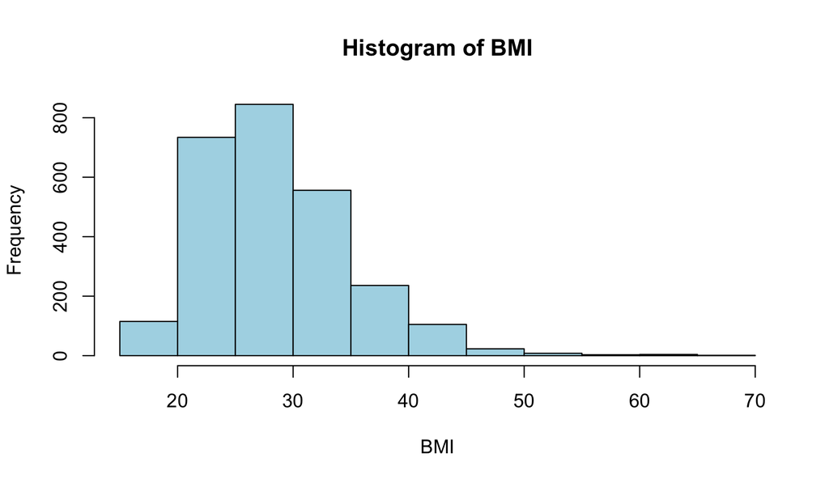

```r
hist(data_clean$BMI,
     main = "Histogram of BMI",
     xlab = "BMI",
     col = "lightblue",
     border = "black")
```

### **2.2. Boxplot of BMI by Gender**

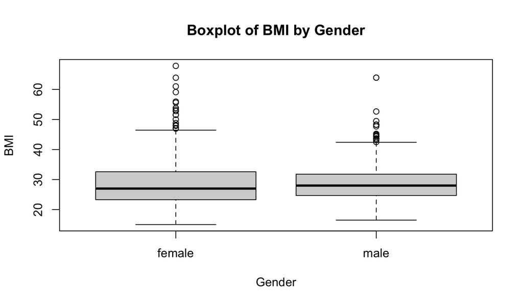

```r
boxplot(BMI ~ Gender, data = data_clean,
        main = "Boxplot of BMI by Gender",
        xlab = "Gender", ylab = "BMI")
```

### 2.3 Scatter Plot

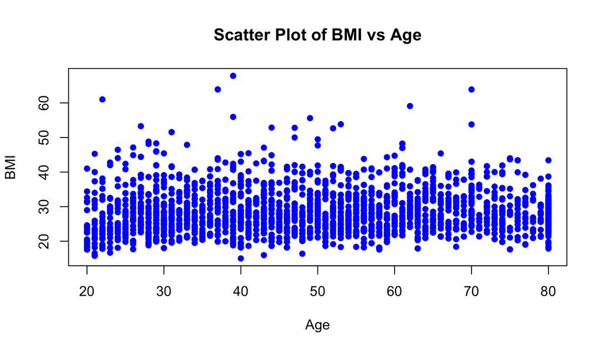

```r
plot(BMI ~ Age, data = data_clean,
     main = "Scatter Plot of BMI vs Age",
     xlab = "Age", ylab = "BMI",
     col = "blue", pch = 16)
```

## **3. Why Use ggplot2?**

- **Layering:** ggplot2 allows adding multiple layers (points, lines, etc.).
- **Faceting:** Easily split data across categories.
- **Customization:** Control over themes, labels, and scales.
- **Aesthetics:** Consistent look and feel with better visualization options.

## **4. Step-by-Step Plotting with ggplot2**

### **4.1. Basic Scatter Plot: Age vs BMI**

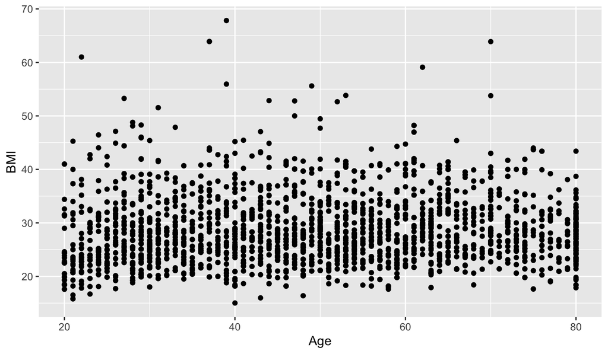

```r
# Basic scatter plot
ggplot(data_clean, aes(x = Age, y = BMI))+
  geom_point()
```

### **4.2. Adding Color and Titles**

- Color helps differentiate genders, and titles make the plot easier to interpret.

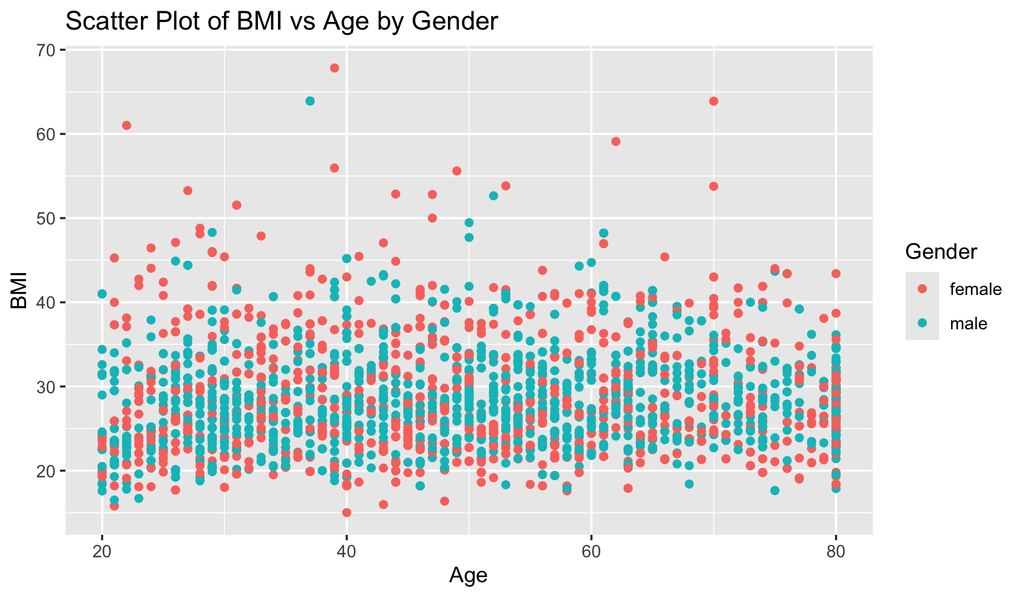

```r
# Scatter plot with color and labels
ggplot(data_clean, aes(x = Age, y = BMI, color = Gender)) +
  geom_point() +
  labs(title = "Scatter Plot of BMI vs Age by Gender",
       x = "Age", y = "BMI")
```

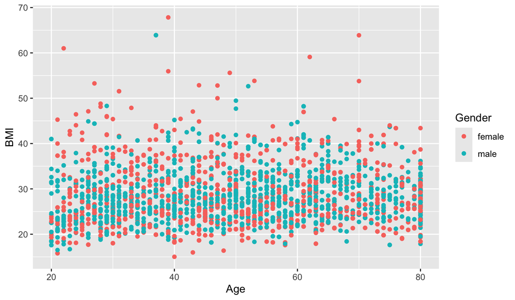

```r
ggplot(data_clean, aes(x = Age, y = BMI, color = Gender))+
  geom_point()
```

### **4.3. Adding a Trend Line**

- **`geom_smooth()`** helps visualize trends in data.
- **Alpha transparency** avoids overplotting by making points semi-transparent.

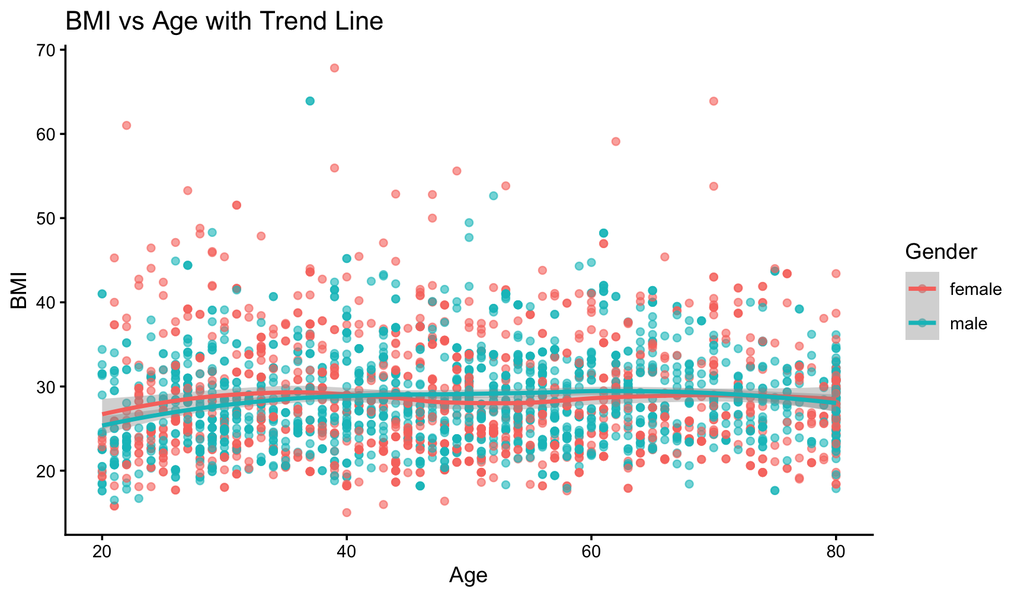

```r
# Scatter plot with a smooth trend line
ggplot(data_clean, aes(x = Age, y = BMI, color = Gender)) +
  geom_point(alpha = 0.6) +
  geom_smooth(method = "loess", se = T) +
  labs(title = "BMI vs Age with Trend Line", x = "Age", y = "BMI")+
  theme_classic()
```

Locally estimated scatterplot smoothing (loess)

Locally estimated scatterplot smoothing, or LOESS, is **a nonparametric method for smoothing a series of data in which no assumptions are made about the underlying structure of the data**.

### **4.4. Faceted Plots**

- **Faceting** splits the data into smaller plots by categories (like marital status), making patterns easier to spot.

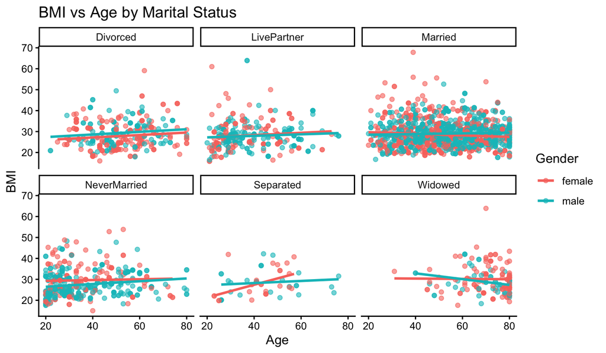

```r
# Facet by Marital Status
ggplot(data_clean, aes(x = Age, y = BMI, color = Gender)) +
  geom_point(alpha = 0.6) +
  geom_smooth(method = "lm", se = FALSE) +
  facet_wrap(~MaritalStatus) +
  labs(title = "BMI vs Age by Marital Status", x = "Age", y = "BMI")+
  theme_classic()
```

### **4.5. Bar Plot: Gender Distribution**

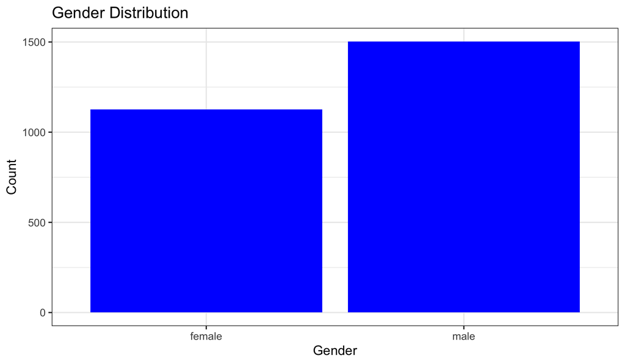

```r
# Bar plot of gender distribution
ggplot(data_clean, aes(x = Gender)) +
  geom_bar(fill = "blue") +
  labs(title = "Gender Distribution", x = "Gender", y = "Count")+
  theme_bw()
```

`geom_bar()` automatically counts observations for categorical variables.

### **4.6. Boxplot: BMI by Depression Levels**

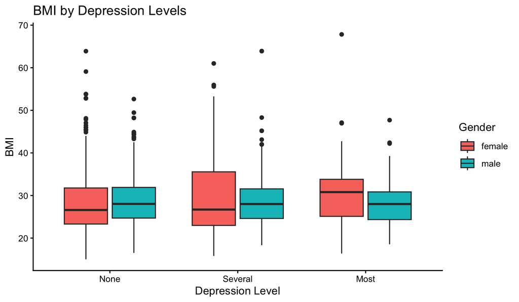

```r
# Boxplot of BMI by Depression Levels
ggplot(data_clean, aes(x = Depressed, y = BMI, fill = Gender)) +
  geom_boxplot() +
  labs(title = "BMI by Depression Levels", x = "Depression Level", y = "BMI")+theme_classic()
```

## Exercise

### Exercise 1: Inspect the Age Distribution of Our Sample

- Create a **histogram of Age** using `ggplot2`.
- Customize it by changing the **binwidth** and **color**.

### **Exercise 2: Scatter Plot with Additional Aesthetic Mappings**

1. Create a **scatter plot** of `BMI` vs `HHIncomeMid`.
2. **Color the points by Gender** and **use alpha transparency** to avoid overplotting.

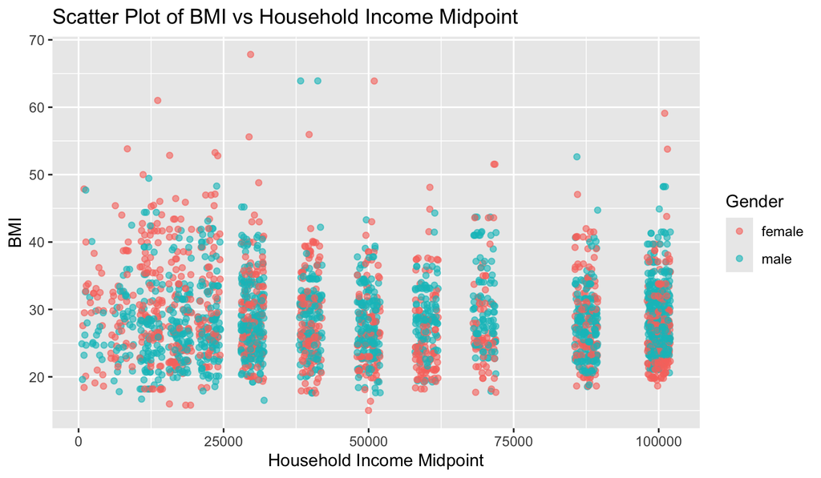

```r
# Scatter plot of BMI vs Income
ggplot(data_clean, aes(x = HHIncomeMid, y = BMI, color = Gender)) +
  geom_jitter(alpha = 0.6) +
  labs(title = "Scatter Plot of BMI vs Household Income Midpoint",
       x = "Household Income Midpoint", y = "BMI")
```

### **Exercise 3: Adding Trend Lines**

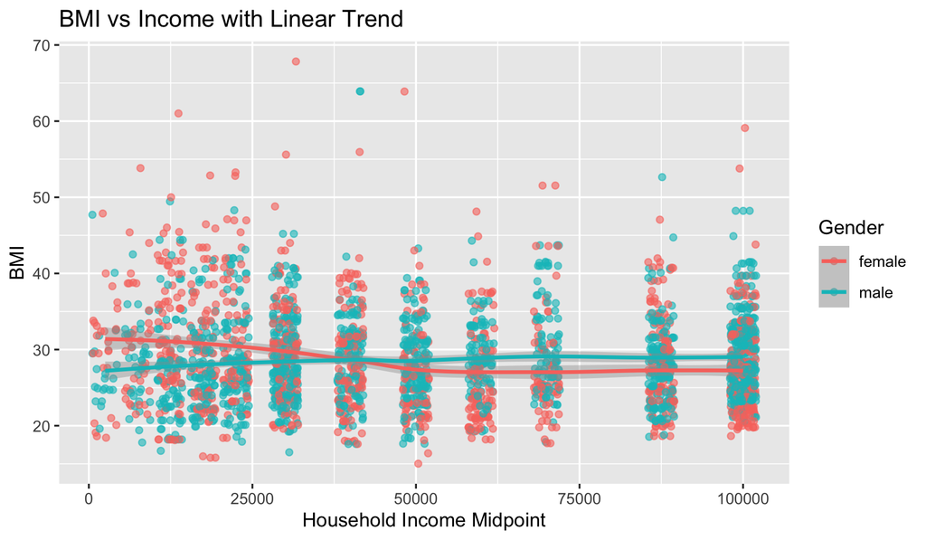

```r
# Scatter plot with a linear trend line
ggplot(data_clean, aes(x = HHIncomeMid, y = BMI, color = Gender)) +
  geom_jitter(alpha = 0.6) +
  geom_smooth(method = "loess",)+
  labs(title = "BMI vs Income with Linear Trend",
       x = "Household Income Midpoint", y = "BMI")
```

### **Exercise 4: Faceting with Multiple Categories**

1. Create a **scatter plot of Age vs BMI** and facet it by **Smoking Status (`SmokeNow`)**.
2. Use **different colors for Gender** and add a **smooth trend line**.

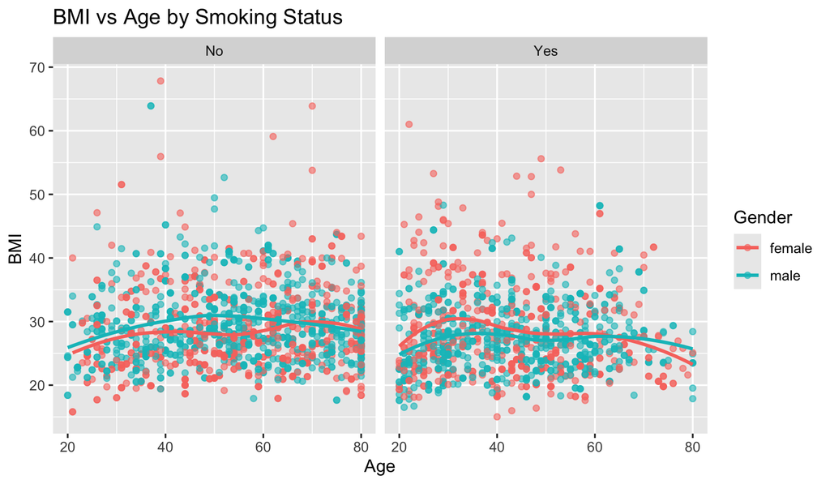

```r
# Faceted scatter plot by Smoking Status
ggplot(data_clean, aes(x = Age, y = BMI, color = Gender)) +
  geom_point(alpha = 0.6) +
  geom_smooth(method = "loess", se = FALSE) +
  facet_wrap(~SmokeNow) +
  labs(title = "BMI vs Age by Smoking Status", x = "Age", y = "BMI")
```